# ss628_eas503_hw3

## EAS 503 Homework 3 Submission

Name - *SHUBHAM SHARMA*

**Make sure that you rename the notebook file to *replacewithubitname*_eas503_hw3.ipynb**

### Submission Details

- **Due Date** - November 13, 2018 by 11:59 PM EST. All assignments have to be submitted using UBLearns.
- **Number of Problems** - 3
- **Maximum points** - 100
- **Collaboration policy**
  - Every student has to submit individual homeworks
  - Any collaboration, in the form of discussion, with other members of the class is permitted, as long as the names of the collaborating members are explicitly stated on top of the submitted homework.
  - Any overlap with another submission or material from Internet will be awarded an F.
- **Late submission policy** - *No late submissions allowed*
- **Submission Format** - Enter code for each problem in the appropriate cell below. You may use multiple cells for a single problem to improve readability.

### Problem 1 - Using regular expressions in `Python` (50 points)

In this problem you will write a rudimentary web crawler to extract information from `Wikipedia`.

The three requirements for this problem are:

##### 1. Get a chronological list of US Presidents from the [List of Presidents of the United States](https://en.wikipedia.org/wiki/List_of_Presidents_of_the_United_States) wikipedia entry (20 points).

You will have to write a function called `getPresidents(url)` which takes one argument, a string containing the url, and returns the list of URLs for the wikipedia pages for each US President in the chronological order of their presidency, i.e., `['https://en.wikipedia.org/wiki/George_Washington', 'https://en.wikipedia.org/wiki/John_Adams'] ...`

The url argument to the function should be - https://en.wikipedia.org/wiki/List_of_Presidents_of_the_United_States

You will notice that one president, Grover Cleveland, will appear twice. For his case, remove the second entry. Reason he comes twice will be apparent once you visit his entry on `Wikipedia`. While there you will also notice that he was the Mayor of Buffalo once, which is why we have the Grover Cleveland Highway in South Campus.

To write this function you will need to use the module `requests` which allows grabbing the html from any url. For instance:

```
import requests
import re

url = "https://www.cse.buffalo.edu"
urlreq = request.get(url)
urltext = urlreq.txt
urllines = re.split(r'\n',urltext)
```

In the above snippet, urllines will be a `list` containing lines of the html code in the above website.

You will then write a parser that will go through the html lines and extract the list of presidents. You can check the actual page to see where that list is.

**Note:** No points will be awarded to this problem if you have manually created the list or derived the list from an alternative url.

##### 2. Parse each President entry in `Wikipedia` and extract his date of birth. (20 points)

On each President's wikipedia entry, the `infobox` on the right lists, among other things, his exact birthday. Implement a function, called `getBirthdays(urls)` which takes as input the list that is returned by the above implemented `getPresidents(url)` function and returns a `Pandas` `TimeSeries` object, that simply contains the names of the Presidents as the value, and the birthdate as the time index.

##### 3. Plot an annotated `timeline` plot using `matplotlib`. (10 points)

Use `matplotlib` routines to plot **time line** of the US presidents, where the x-axis corresponds to time from 1720 until 2000 and y-axis denotes the birthdate for each president. The timeline plot should look similar to:

[figure not shown]

You will need to adjust the heights, font sizes, etc., to make it look clean.

Note that there is not direct function for plotting a module, you will just need to iterate over the values to create several overlaid plots with desired effects.

#### Points breakup:

This problem is worth 50 points, and first two subparts are worth 20 points each. For the plotting subpart, a clean looking plot with all information will fetch you 10 points. A cluttered plot, with all information, will only fetch you 5 points.

```python
import numpy as np
import pandas as pd
import requests
import re
from datetime import datetime as dt
import matplotlib.pyplot as plt
import numpy as np
import matplotlib.dates as mdates

def getPresidents(url):
    u_req = requests.get(url)
    u_T = u_req.text
    UL = re.split(r'\n',u_T)
    UL1=re.findall(r'(<big><a href="(.*?)")',u_T)

    pres=list() # creating an empty list to add the names of the presidents
    for k in range(len(UL1)):
        pres.append('https://en.wikipedia.org/' + str(UL1[k][1])) # Appending the list along with wiki URL

    def fun(a):
        s = set()
        s_add = s.add
        return [t for t in a if not (t in s or s_add(t))]
    return fun(pres)
```

```python
def getBirthdays(pres):
    bdays = []
    N = []
    for ele in range(len(pres)):
        urlreq = requests.get(pres[ele])
        urltext = urlreq.text
        urllines = re.findall(r'<span class="bday">(.*?)</span>\)',urltext)
        urlN = re.findall(r'"wgTitle":"(.*?)"',urltext)
        bdays.append(dt.strptime(urllines[0], '%Y-%m-%d'))
        N.append(urlN[0])
    ser = pd.Series(N, index=bdays)
    return ser

url = ('https://en.wikipedia.org' + "/wiki/List_of_Presidents_of_the_United_States")
```

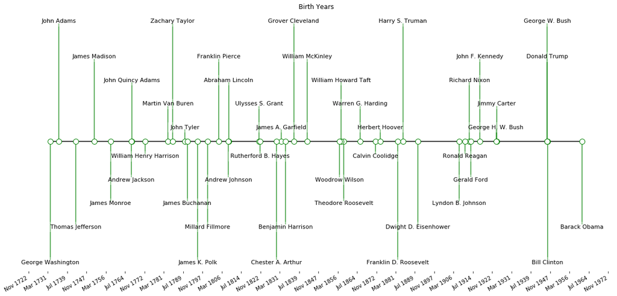

```python
URL_P = getPresidents(url)
URL_P = list(dict.fromkeys(URL_P))

ser = getBirthdays(URL_P)

list_birthday = ser.index.tolist()
list_names = ser.values.tolist()

levels = np.array([-10,10,-7,7,-5, 5, -3, 3, -1, 1])
fig, ax = plt.subplots(figsize = (20, 10))

ax.plot((min(list_birthday), max(list_birthday)), (0, 0), 'k', alpha = 1)

for ii, (ibday, iname) in enumerate(zip(list_birthday, list_names)):
    level = levels[ii % 10]
    vert = 'top' if level < 0 else 'bottom'
    ax.scatter(ibday, 0, s = 100, facecolor = 'w', edgecolor = 'g', zorder = 9999)
    ax.plot((ibday, ibday), (0, level), c = 'g', alpha = .8)

    ax.text(ibday, level, iname,
            horizontalalignment = 'center', verticalalignment = vert, fontsize = 11,
            backgroundcolor = (1., 1., 1., .3))
ax.set(title = "Birth Years")

ax.get_xaxis().set_major_locator(mdates.MonthLocator(interval = 100))
ax.get_xaxis().set_major_formatter(mdates.DateFormatter("%b %Y"))
fig.autofmt_xdate()

plt.setp((ax.get_yticklabels() + ax.get_yticklines() +
          list(ax.spines.values())), visible = False)
plt.show()
```

### Problem 2 - Chicago Crime Data (25 points)

The Chicago Crime Data reflects the crime incidents that occured in the city of Chicago during 2016 and 2017. The data is provided in the `chicago_crime_data_v3.csv` file. For each crime incident, there is information regarding the case ID, crime location, description, primary crime type ID, coordinates of the crime etc. To identify the primary crime type (denoted by the `Primary type` variable), the `primary_type_ID.csv` file is provided which maps the primary crime type to their corresponding ID.

For this problem, the goal is to identify the crime types that have occurred more than 10,000 times during the years 2016 and 2017. For this,

1. Import the CSV files as dataframes using pandas.
2. Sort the crime data file by crime ID and merge the two files by `Primary Type ID` variable.
3. Identify the crime types that have a frequency >10,000 and list them as `High Frequency Crime Types`. Provide a timeseries plot for all `High Frequency Crime Types`. For this, compute the number of crimes that occur per each crime type per month (2016 Jan - 2017 Dec). Use the `series.plot` method in Pandas for Series objects.
4. Using the code provided below, plot all the crimes that come under `High Frequency Crime Types` on a map of Chicago. For this, use the location information provided in the data. For any crimes with missing location coordinates, sort the data by ascending `Date` and use forward fill.

(Make sure that each data point must be plotted as a transparent circular dots with a markersize of atleast 20 and alpha set to atmost 0.5 (transparency))

*Installation Notes*: You will need the `basemap` package. You can get that using:

```
script
conda install basemap
```

Due to some bug in the way `conda` maintains environmental variables, the following import statement might not work:

```
from mpl_toolkits.basemap import Basemap
```

If it does not work on your computer, try the following:

```
import os,conda

conda_file_dir = conda.__file__
conda_dir = conda_file_dir.split('lib')[0]
proj_lib = os.path.join(os.path.join(conda_dir, 'share'), 'proj')
os.environ["PROJ_LIB"] = proj_lib

from mpl_toolkits.basemap import Basemap
```

```python
from datetime import datetime as dt
import pandas as pd
import numpy as np
import matplotlib.pyplot as plt
%matplotlib inline
import os,conda

data = pd.read_csv("chicago_crime_data_v3.csv")
ptype = pd.read_csv("primary_type_id.csv")

data['Date'] = data['Date'].astype('datetime64[ns]')   # changing the format of date to datetime64[ns]
data['Month'] = data['Date'].dt.strftime('%Y-%m')
data['month_year'] = data['Month'].astype(str)

# data.head()
# data.isnull().any() : to check null/NA/NaN values in the data, we see some of the location information is missing
# data[data['Location'].isnull()].shape : 22902 rows have NaN for location value
# Sorting the dataframe by crime ID in ascending order

sdata = data.sort_values(['Cime_ID'], ascending = True,  inplace = False, kind='quicksort')
smdata = pd.merge(sdata, ptype, on = "Primary Type ID")
smdata_grp = smdata.groupby('Primary Type ID').count()
HF = smdata_grp.query('Cime_ID>=10000')

print("The high frequency crime types are as follows:")
print()
print(FLN['Primary Type'])

TV = pd.merge(HF, ptype, on = "Primary Type ID")
TV2 = pd.merge(TV, ptype, on = "Primary Type ID")

FLD = TV2[['Primary Type ID','Cime_ID']]
# Dataframe having Primary type ID and crime name
FLN = pd.merge(FLD, ptype, on = "Primary Type ID")


PID_val = FLN['Primary Type ID'].values
FD = sdata.loc[sdata['Primary Type ID'].isin(PID_val)]

Temp_FD = FD.sort_values(['Date'], ascending = True,  inplace = False, kind='quicksort')
FD_plot = Temp_FD.fillna(method = 'ffill')   #forward filling for NaN values of location

FD_counts = FD_plot.groupby(['Primary Type ID','month_year'], as_index = False).count()
```

[output not shown]

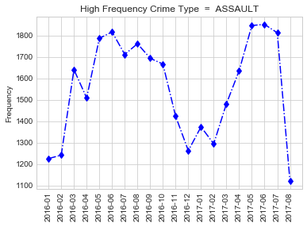

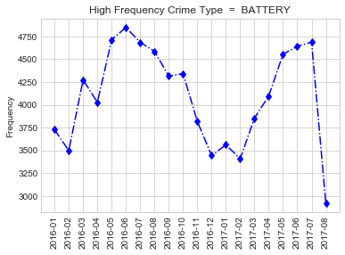

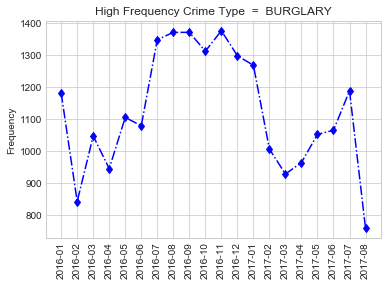

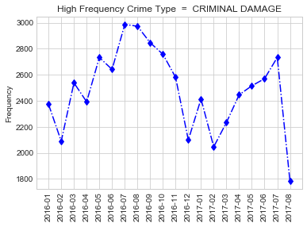

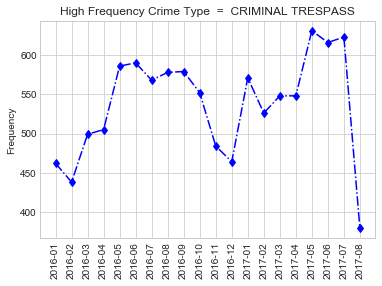

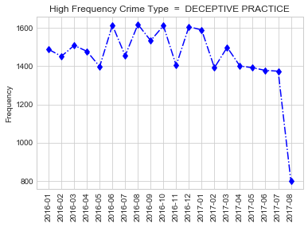

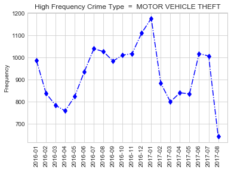

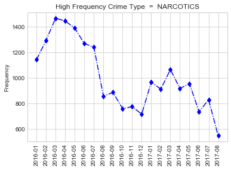

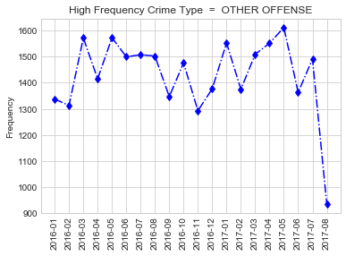

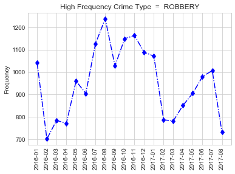

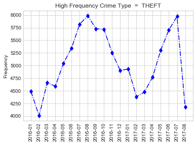

```python
FD_cntf = pd.merge(FD_counts, ptype, on = "Primary Type ID")
plt.style.use('seaborn-whitegrid')
for i in sorted(set(FD_cntf['Primary Type'])):
    df = FD_cntf[FD_cntf['Primary Type'] == i].sort_values('month_year', ascending = True)
    sp = pd.Series(df['Cime_ID'].values,index = df['month_year'])
    plt.plot(df['month_year'], df['Cime_ID'],linestyle = '-.', marker = 'd', color = 'b')
    plt.title(f'High Frequency Crime Type  =  {i}')
    plt.ylabel('Frequency')
    plt.xticks(rotation=90)
    plt.show()
```

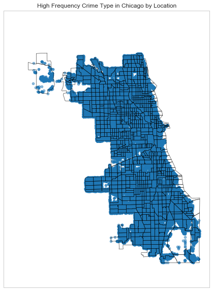

```python
conda_file_dir = conda.__file__
conda_dir = conda_file_dir.split('lib')[0]
proj_lib = os.path.join(os.path.join(conda_dir, 'share'), 'proj')
os.environ["PROJ_LIB"] = proj_lib

from mpl_toolkits.basemap import Basemap

fig = plt.figure(figsize=[16,10])
map_1 = Basemap(projection='merc',llcrnrlat=41.60,urcrnrlat=42.10,llcrnrlon=-88.0,urcrnrlon=-87.50,lat_ts=20,resolution='c')
map_1.readshapefile('./geo_export_0e3da441-8fe8-4e11-9ca0-42ef75cab68e','chicago')

lt = FD_plot['Latitude'].values.astype(float)
ln = FD_plot['Longitude'].values.astype(float)

x,y = map_1(ln,lt)
plt.scatter(x,y,alpha=0.5,s=21)
plt.title("High Frequency Crime Type in Chicago by Location")
plt.show()
```

### Problem 3 - Benchmarking Problem (25 Points)

Numpy has in-built universal functions that allow operations on multidimentional arrays. For this problem, you will be asked to test the performance of some of this functions.

For this, create an `NxN` matrix `A` and an array `B` of size `N`, with random entries (use `numpy.random`). Using `A` and `B` as inputs, performing the following operations: (compare and time the performance of sorting algorithms with and without numpy ufunc)

1. Sorting `B` (you can use `numpy.sort`) for `N` ranging from 1000 to 25000 (take steps of 1000)
2. Computing Determinant of `A` ( you can use `numpy.linalg.det` to compute the determinant of the matrix) for `N` ranging from 100 to 800 (take steps of 50)
3. Matrix Multiplication of `A*A` ( use `numpy.matmul`) for `N` ranging from 100 to 1500

Plot the operation times for Numpy functions vs regular python commands for each operation.

The final output must include 3 plots comparing the performance of universal functions in Numpy with similar analogs in python for each operation. Provide a breif interpretation from the plots. (Feel free to test around the range of `N` for this problem).

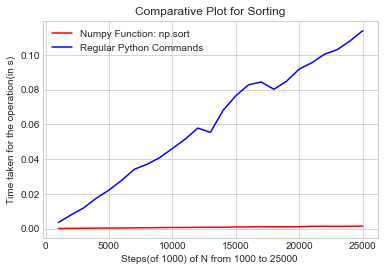

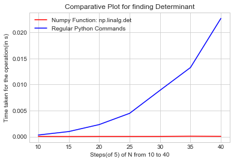

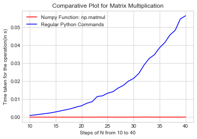

```python
#Question 3

import numpy as np
import time
import matplotlib.pyplot as plt
%matplotlib inline

def QS(A):
    # Function to do quicksort
    QSR(A,0,len(A)-1)

def QSR(A,F,L):
    if F<L:
        split = splitf(A,F,L)
        QSR(A,F,split-1)
        QSR(A,split+1,L)

def splitf(A,F,L):
    P = A[F]
    LM = F+1
    RM = L
    done = False
    while not done:
        while LM <=RM and A[LM]<=P:
            LM +=1
        while A[RM] >= P and RM >=LM:
            RM -=1
        if RM < LM:
            done = True
        else:
            A[LM], A[RM] = A[RM], A[LM]
    A[F], A[RM] = A[RM], A[F]

    return RM

## Sorting

ln1 = [] # list to store numpy function times
lp1 = [] # list to store regular python commands time
x1 = [] # list to store steps
for i in range (1000, 25001, 1000):
    np.random.seed(12345)
    B = np.random.randn(i)

    # Numpy function
    st = time.time()
    np.sort(B)
    en = time.time()
    ln1.extend([(en-st)])
    x1.extend([i])

    # Regular Python Commands
    st = time.time()
    QS(B)
    en = time.time()
    lp1.extend([(en-st)])

fig1 = plt.figure()
plt.plot(x1, ln1, 'r') #red
plt.plot(x1, lp1, 'b') #blue
plt.xlabel("Steps(of 1000) of N from 1000 to 25000 ")
plt.ylabel("Time taken for the operation(in s)")
plt.title("Comparative Plot for Sorting")
plt.legend(['Numpy Function: np.sort', 'Regular Python Commands'])


def cal_det(A):
    # LU Decomposition
    L = np.eye(len(A))
    U = A
    m = A.shape[0]
    n = A.shape[1]

    for i in range(m - 1):
        for j in range(i + 1, n):
            L[j][i] = U[j][i] / U[i][i]
            U[j][i] = 0

            for k in range(i + 1, n):
                U[j][k] -= L[j][i] * U[i][k]
    D = 1
    for i in range(m):
        D *= L[i][i] * U[i][i]
    return D

ln2 = [] # list to store numpy function times
lp2 = [] # list to store regular python commands time
x2 = [] # list to store steps

for i in range (10, 41, 5):
    np.random.seed(12345)
    A = np.random.randn(i**2).reshape((i,i))

    # Numpy function
    st = time.time()
    b = np.linalg.slogdet(A) # log of determinant value calculated to avoid overflow
    en = time.time()
    ln2.extend([(en-st)])
    x2.extend([i])

    # Regular Python Commands
    st = time.time()
    b = cal_det(A)
    en = time.time()
    lp2.extend([(en-st)])


fig2 = plt.figure()
plt.plot(x2, ln2, 'r') #red
plt.plot(x2, lp2, 'b') #blue
plt.xlabel("Steps(of 5) of N from 10 to 40")
plt.ylabel("Time taken for the operation(in s)")
plt.title("Comparative Plot for finding Determinant")
plt.legend(['Numpy Function: np.linalg.det', 'Regular Python Commands'])



## Matrix Multiplication

def mul_mat(X,Y):
    r = np.zeros((X.shape[0],Y.shape[1]))
    for i in range(len(X)):
        for j in range(len(Y[0])):
            for k in range(len(Y)):
                r[i][j] += X[i][k] * Y[k][j]
    return r

ln3 = [] # list to store numpy function times
lp3 = [] # list to store regular python commands time
x3 = [] # list to store steps

for i in range (10, 41):
    np.random.seed(12345)
    A = np.random.randn(i**2).reshape((i,i))

    # Numpy function
    st = time.time()
    c = np.matmul(A,A)
    en = time.time()
    ln3.extend([(en-st)])
    x3.extend([i])

    # Regular Python Commands
    st = time.time()
    c = mul_mat(A,A)
    en = time.time()
    lp3.extend([(en-st)])

fig3 = plt.figure()
plt.plot(x3, ln3, 'r') #red
plt.plot(x3, lp3, 'b') #blue
plt.xlabel("Steps of N from 10 to 40")
plt.ylabel("Time taken for the operation(in s)")
plt.title("Comparative Plot for Matrix Multiplication")
plt.legend(['Numpy Function: np.matmul', 'Regular Python Commands'])
```

From the plot for Sorting, a function for Quicksort was implemented using Regular Python commands and compared to np.sort(). We observe that initially the time taken to execute both functions are close initially but the difference between them increases as the size of the array grows and the time for Regular Python commands increases for all the three plots.

This is what was expected, since the numpy functions pushes the expensive computation of for loops into lower level language i.e. C which make it more efficient. We know that the standard Python implementation is written in C and every Python object is simply a cleverly-disguised C structure which has other information as well apart from the value like reference count, type of variable, its size etc. Although, this type of implementation makes Python a very effective tool as a coding language in terms of the flexibility it offers, but this makes it slower which is apparent in the three graphs. The numpy universal functions’ implementation does all the expensive computation at a lower level thus making it more efficient.

Note: The loop for calculating determinant shortened to 10 to 40 and for matrix multiplication from 10 to 40 to avoid delay due to loop running time and the plot obtained conveys the idea.